# Lecture 27: Power/inverse iteration

## Rayleigh quotient

Suppose $A$ is $m\times m$. We can define a function called the **Rayleigh quotient**,

$$ r(v) = \frac{v^*Av}{v^*v}, $$

for all $v\in\mathbb{C}^m$. As shown in the text, the stationary points of $r$ are the eigenvectors of $A$. More specifically, if $v$ is close to an eigenvector $x$ with eigenvalue $\lambda$, then

$$ |r(v)-\lambda| = O\bigl( \|v-x\|_2 \bigr) $$

in general, and

$$ |r(v)-\lambda| = O\bigl( \|v-x\|_2^2 \bigr) $$

if $A$ is hermitian. Thus we can turn an eigenvector estimate into an eigenvalue estimate.

For example, let

```matlab
A = [2 1 1; 1 3 1; 1 1 4]
[V,D] = eig(A);
```

```
A =

     2     1     1
     1     3     1
     1     1     4
```

We'll color the unit sphere according to the value of the Rayleigh quotient at each point on it.

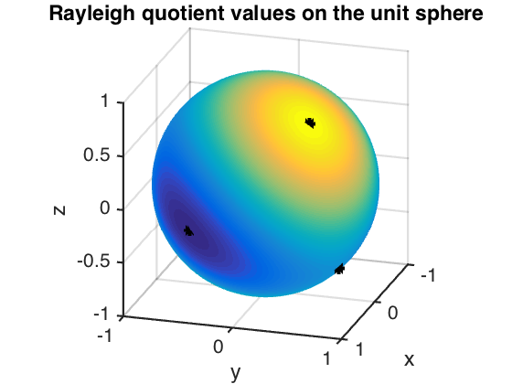

```matlab
[X,Y,Z] = sphere(100);
v = [X(:) Y(:) Z(:)]';
Av = A*v;
Ray = sum( conj(v).*Av, 1 );
surf(X,Y,Z,reshape(Ray,size(X)))
hold on
plot3(V(1,:),V(2,:),V(3,:),'k*')

title('Rayleigh quotient values on the unit sphere')
shading interp, axis square
view(107,20)
xlabel('x'), ylabel('y'), zlabel('z')
```

The eigenvectors (their projections onto the sphere) are shown with black markers. The max of $r(v)$ is in the middle of the yellow spot. It's the third eigenvector of $A$ as computed above, and close to $(0.4,0.5,0.75)$.

```matlab
x = V(:,3);
v = [0.4;0.5;0.75];
evec_err = norm(x-v)
```

```
evec_err =

    0.0216
```

```matlab
eval_est = v'*A*v/(v'*v)
eval_err = norm(eval_est-D(3,3))
```

```
eval_est =

    5.2134


eval_err =

   9.5213e-04
```

## Power iteration

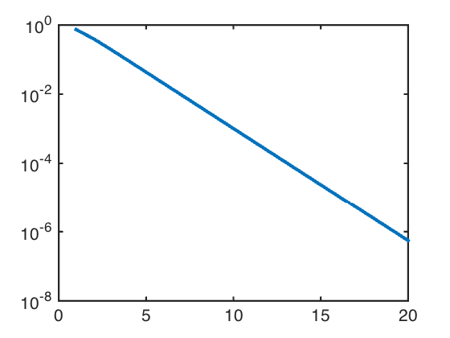

```matlab
v = rand(3,1);
for k = 1:20
    v = v/norm(v);
    evec_err(k) = min(norm(v-x),norm(v+x));
    v = A*v;
end
semilogy(evec_err)
```

Since $A$ is symmetric, we should expect around 12 accurate digits in an eigenvalue estimate derived from a Rayleigh quotient with our final $v$.

```matlab
abs( v'*A*v/(v'*v) - D(3,3) )
```

```
ans =

   1.9007e-13
```

```matlab
diag(D)
```

```
ans =

    1.3249
    2.4608
    5.2143
```

```matlab
(5-5.2)/(5-2.46)
```

```
ans =

   -0.0787
```

Now how much would you pay? But wait--there's more!

## Inverse iteration

If $\lambda_J$ is an eigenvalue of $A$, then $(\lambda_J-\mu)^{-1}$ is an eigenvalue of $(A-\mu I)^{-1}$, with the same eigenvector. If $\mu$ is closer to $\lambda_J$ than to any other $\lambda_j$, a power iteration on $(A-\mu I)^{-1}$ should converge very quickly. This amounts to repeatedly solving a linear system with the matrix $(A-\mu I)$.

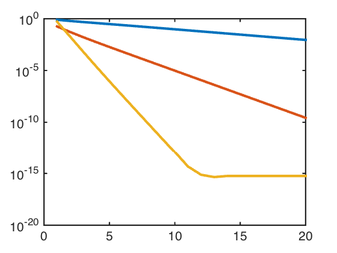

```matlab
for mu = [4 4.5 5.1]
    [L,U] = lu(A-mu*eye(3));
    v = rand(3,1);
    for k = 1:20
        v = v/norm(v);
        evec_err(k) = min(norm(v-x),norm(v+x));
        v = U\(L\v);
    end
    semilogy(evec_err)
    hold on
end
```

## Rayleigh quotient iteration

The coup de grâce: a better shift means a better eigenvector estimate, which means a better eigenvalue estimate, which is an even better shift, etc. This feedback loop causes *cubic* convergence in the hermitian case, which is rare--and fast! It's so fast that we pretty well need extended precision to see it.

```matlab
digits(60)
A = vpa(A);
lambda = eig(A)
```

```
lambda =

 5.21431974337753518741549770084858048890791963721949943433138
 2.46081112718911088347412409730147999190011289045787329828077
 1.32486912943335392911037820184993951919196747232262726738785
```

```matlab
v = vpa(ones(3,1));
for k = 1:5
    v = v/norm(v);
    mu = v'*A*v;
    fprintf('error in eigenvalue = %.50f\n',double(min(mu-lambda)))
    v = (A-mu*eye(3))\v;
end
```

```
error in eigenvalue = -0.21431974337753517678706316473835613578557968139648
error in eigenvalue = -0.00120498927917453164254668607213716313708573579788
error in eigenvalue = -0.00000000019350335636704886234483316195391670519466
error in eigenvalue = -0.00000000000000000000000000000086272041087647542775
error in eigenvalue = 0.00000000000000000000000000000000000000000000000000
[Warning: The system is inconsistent. Solution does not exist.]
[> In symengine (line 57)
  In sym/privBinaryOp (line 903)
  In \ (line 309)
  In pymat_eval (line 31)
  In matlabserver (line 24)]
```

Count 'em: The number of leading zeros *at least triples* with each iteration, and in 5 iterations we get 60 digits of accuracy. 😎